# Lesson 17: Inference for One Proportion

Homework

- Word Document
- PDF Document

## Solutions

**Please note that the steps show rounded numbers, but that the final answers to the problems are calculated without rounding.**

Problem

Part

Solution

1

-

$n \hat{p} \geq 10$  
$n(1 - \hat{p}) \geq 10$  
$100(0.12) = 12 \geq 10$  
$100(1 - 0.12) = 88 \geq 10$  
The requirements are met.

2

-

$\hat{p} = 0.12$

3

-

(0.067, 0.173) We are 90% confident that the true proportion of peanuts in the can is between 6.7% and 17.3%.

4

-

$n p \geq 10$  
$n(1 - p) \geq 10$  
$100(0.2) = 20 \geq 10$  
$100(1 - 0.2) = 80 \geq 10$  
Since both conditions are true, we conclude that $n$ is sufficiently large so that $\hat{p}$ will be approximately distributed.

5

-

$\hat{p} = 0.12$

6

-

$H_0: p = 0.2$  
$H_a: p < 0.2$

7

-

$z = -2$

8

-

$P-value = 0.0228$

9

-

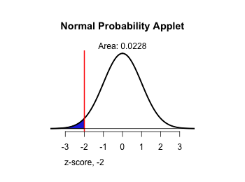

10

-

reject the null hypothesis

11

-

There is sufficient to suggest that the proportion of peanuts in the can is less than 20%.

12

-

(0.023, 0.024) We are 95% confident that the true proportion of the population who die after contracting H1N1 is between 2.3% and 2.4%.

13

-

(0.547, 0.639) We are 95% confident that the true proportion of the population who die after contracting H5N1 is between 54.7% and 63.9%.

14

-

The bird flu (H5N1) is by far more deadly! More than half of those who contract the bird flu will die, compared to only 2 to 3% of those who are infected with the swine flu. Fortunately for us, the bird flu is currently onlypassed to humans through contact with infected birds. Epidemiologists are concerned about a global pandemic of this disease, which would almost surely happen if the virus mutates to allow human-to-human transmission.

15

-

$n = 423 \text{ people}$

16

-

$n = 334 \text{ people}$

17

-

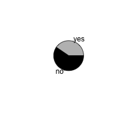

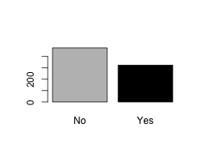

18

-

$n p \geq 10$  
$n(1 - p) \geq 10$  
$800(0.43) = 344 \geq 10$  
$800(1 - 0.43) = 456 \geq 10$  
Since both conditions are true, we conclude that $n$ is sufficiently large so that $\hat{p}$ will be approximately distributed.

19

-

$\hat{p} = 0.405$

20

-

$H_0: p = 0.43$  
$H_a: p \neq 0.43$

21

-

$z = -1.428$

22

-

$P-value = 0.1532$

23

-

fail to reject the null hypothesis

24

-

There is insufficient to suggest that the proportion of adults who received a phishing email in 2012 is different than 43%.